# Lecture

## The sequence to sequence problem

Generative model: $$ p(y|x) \to \max_y $$

- Statistical approach: $$ p(y|x) \propto p(x|y) p(y) $$

  Discriminative model is sometimes easier to learn, but still very tricky.
- Neural approach: $$ p(y|x) = p(y_t | y_{t-1}, y_{t-2}, \ldots, y_1, x) p(y_{t-1} | y_{t-2}, \ldots, y_1, x) \ldots p(y_1 | x) $$

  Each term is a neural network. Better performance, less effort.

## Example: Neural Machine Translation

[figure not shown]

## Problems of sequence to sequence models

[figure not shown]

- Bottleneck
- Hard to keep relevant context in longer texts

## Solution: attention

[figure not shown]

- Encoder RNN produces encoder hidden states ${ \color{blue} h_1, h_2, \ldots, h_N } \in \mathbb{R}^h$
- Decoder RNN has hidden state ${ \color{green} s_t } \in \mathbb{R}^h$ at step $t$
- Attention scores for step $t$ are computed as inner product between encoder and decoder hidden states: $$ { \color{orange} e_{ti} } = { \color{green} s_t^\top } { \color{blue} h_i } \in \mathbb{R} $$
- Attention distribution is obtained via softmax: $$ { \color{orange} \alpha_t } = \operatorname{softmax}({ \color{orange} e_t }) \in \mathbb{R}^N $$
- The final output of attention is a sum of encoder hidden states weighted by the attention distribution: $$ { \color{yellow} a_t } = \sum_{i=1}^N { \color{orange} \alpha_{ti} } { \color{blue} h_i } \in \mathbb{R}^h $$
- Then ${ \color{yellow} a_t }$ is used together with $\color {green} s_t$ for decoding $\color{red} y_t$

## Attention

## Attention advantages

- Significantly improves performance
- Solves the bottleneck problem
- Solves vanishing gradients problem
- Provides interpretability

## Key-value interpretation

Denote

- $q_i$ the query to a database
- $k_j$ the keys in a database
- $v_j$ the values in a database

Then to retrieve a value, we

1. Calculate relevant entries using inner product $e_j = q_i^\top k_j$
2. Normalize the scores with softmax $\alpha = \operatorname{softmax}(e)$
3. Extract value equal to weighted sum of relevant values $a_i = \sum_{i=1}^N \alpha_j v_j$

$$ A = \operatorname{softmax}(QK^\top / {\color{red} \sqrt{d_k}}) V $$

## Transformer

- Completely drop RNN
- There is an encoder and a decoder
- Make many rounds of self-attention

[figure not shown]

## Self-attention

- $A = \operatorname{softmax}(QK^\top / \sqrt{d_k}) V$
- $Q = XW^Q$
- $K = XW^K$
- $V = XW^V$

All the same data!

[figure not shown]

## Multi-head attention

[output not shown]

## Layer Normalization

- Speeds up training
- Similar effect to BatchNormalization
- But can be used with batch size 1

[figure not shown]

## Position encoding

- Without positional encoding there is no sequential information
- Not one-hot for varied sequence length
- But can be used with batch size 1

[figure not shown]

## Transformer derivatives

| Model | Examples | Tasks | Training |
| --- | --- | --- | --- |
| Encoder only | ALBERT, BERT, DistilBERT, ELECTRA, RoBERTa | Sentence classification, named entity recognition, extractive question answering | Masked language modeling |
| Decoder only | CTRL, GPT, GPT-2, Transformer XL | Text generation | Next token prediction |
| Encoder-decoder | BART, T5, Marian, mBART | Summarization, translation, generative question answering | Denoising |

## Problems of transformers

- Costs: GPT-3 train cost is estimated to be 10-50 billion USD
- Data: Llama 3 was trained on over 15T tokens, that's roughly 10 trillion words
- Complexity of self-attention $$ \operatorname{Attention} = \operatorname{softmax}(QK^\top / \sqrt{d_k}) V $$

# Webinar

[figure not shown]

- Encoder RNN produces encoder hidden states ${ \color{blue} h_1, h_2, \ldots, h_N } \in \mathbb{R}^h$
- Decoder RNN has hidden state ${ \color{green} s_t } \in \mathbb{R}^h$ at step $t$
- Attention scores for step $t$ are computed as inner product between encoder and decoder hidden states: $$ { \color{orange} e_{ti} } = { \color{green} s_t^\top } { \color{blue} h_i } \in \mathbb{R} $$
- Attention distribution is obtained via softmax: $$ { \color{orange} \alpha_t } = \operatorname{softmax}({ \color{orange} e_t }) \in \mathbb{R}^N $$
- The final output of attention is a sum of encoder hidden states weighted by the attention distribution: $$ { \color{yellow} a_t } = \sum_{i=1}^N { \color{orange} \alpha_{ti} } { \color{blue} h_i } \in \mathbb{R}^h $$
- Then ${ \color{yellow} a_t }$ is used together with $\color {green} s_t$ for decoding $\color{red} y_t$
- Matrix form: $$ A = \operatorname{softmax}(QK^\top / {\color{red} \sqrt{d_k}}) V $$

```python
import torch
import numpy as np
import matplotlib.pyplot as plt
from sklearn.model_selection import train_test_split
from tqdm.notebook import tqdm
```

## Similarity scores

Attention scores for step $t$ are computed as inner product between queries and keys: $$ e_{ti} = q_t^\top k_i $$ $$ E = Q K^\top $$

```python
torch.manual_seed(0)
d = 64
t, k = 10, 8
batch_size = 3
query = torch.rand(10, d)
query = query.repeat(batch_size, 1, 1)

key = torch.rand(8, d)
key = key.repeat(batch_size, 1, 1)
```

```python
def scalar_similarity_coefficient(x, y, d):
    return torch.dot(x,y) / np.sqrt(d)
```

```python
def compute_coefficient_matrix(query, key, d):
    return torch.matmul(query, key.transpose(-1, -2)) / np.sqrt(d)
```

```python
coefficient_matrix = compute_coefficient_matrix(query, key, d)

second_query = query[0, 2]
third_key = key[0, 3]

assert torch.allclose(coefficient_matrix[0, 2, 3], scalar_similarity_coefficient(second_query, third_key, d))
assert torch.allclose(coefficient_matrix[0], coefficient_matrix[1])
assert torch.Size([batch_size, t, k]) == coefficient_matrix.shape
```

## Attention distribution

After we obtain the scores, we need to covert them to a distribution using softmax: $$ \alpha_t = \operatorname{softmax}(e_t) $$ $$ \alpha = \operatorname{softmax}(E) $$

```python
torch.manual_seed(2)
d = 64
t,k = 10, 8
batch_size = 3
query = torch.rand(batch_size, 10, d)
key = torch.rand(batch_size, 8, d)
```

```python
def compute_attention_matrix(query, key, d):
    coefficient_matrix = compute_coefficient_matrix(query, key, d)
    attention_matrix = torch.softmax(coefficient_matrix, dim=-1)
    return attention_matrix
```

```python
A = compute_attention_matrix(query, key, d)

assert np.allclose((A.sum(axis=-1) - 1).sum().numpy(), 0, atol=1e-6)
assert torch.all(A >= 0.0)
```

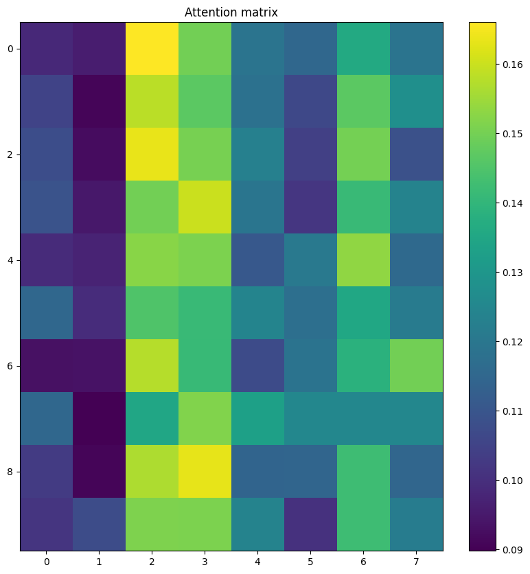

```python
plt.figure(figsize=(10,10))
plt.title('Attention matrix')
plt.imshow(A[0])
plt.colorbar();
```

## Attention

The last step to obtain attention is to пуе a sum of encoder hidden states weighted by the attention distribution: $$ a_t = \sum_{i=1}^N \alpha_{ti} v_i $$ $$ A = \alpha V, $$

```python
torch.manual_seed(6)
d = 64
t, k = 10, 8
batch_size = 3
query = torch.rand(batch_size, t, d)
key = torch.rand(batch_size, k, d)
value = torch.rand(batch_size, k, d)
```

```python
def attention(query, key, value, d):
    coefficient_matrix = compute_coefficient_matrix(query, key, d)
    attention_matrix = torch.softmax(coefficient_matrix, dim=-1)
    out = torch.matmul(attention_matrix, value)
    return attention_matrix, out
```

```python
A, out = attention(query, key, value, d)
assert out.shape == query.shape
assert torch.allclose(out.sum(), torch.tensor(973.154541015625))
```

## Attention layer

In real applications we additionally use a linear projection operator before computing attention. This way the model can view the data in the most efficient way:

- $A = \operatorname{softmax}(Q'K'^\top / \sqrt{d_k}) V'$
- $Q' = QW^Q$
- $K' = KW^K$
- $V' = VW^V$

```python
d = 32
t, k = 10, 8
batch_size = 3
query = torch.rand(batch_size, t, d)
key = torch.rand(batch_size, k, d)
value = torch.rand(batch_size, k, d)
```

```python
class AttentionLayer(torch.nn.Module):
    def __init__(self, d):
        super().__init__()
        # self.q_layer = # TODO: Trainable projection layer
        # self.k_layer = # TODO: Trainable projection layer
        # self.v_layer = # TODO: Trainable projection layer
        self.q_layer = torch.nn.Linear(d, d)
        self.k_layer = torch.nn.Linear(d, d, bias=False)
        self.v_layer = torch.nn.Linear(d, d)
        self.d = d

    def forward(self, query, key, value):
        self.q_proj = self.q_layer(query)
        self.k_proj = self.k_layer(key)
        self.v_proj = self.v_layer(value)
        self.A, out = attention(self.q_proj, self.k_proj, self.v_proj, self.d)
        return out
```

```python
att_layer_out = AttentionLayer(32)(query, key, value)
assert att_layer_out.shape == query.shape
assert not torch.allclose(attention(query, key, value, d)[1], att_layer_out)
```

## Self-attention

Often, especially in NLP, attention is used simply as a feature generator. In this case, it makes sense to apply it to the same data:

- $A = \operatorname{softmax}(QK^\top / \sqrt{d_k}) V$
- $Q = XW^Q$
- $K = XW^K$
- $V = XW^V$

```python
d = 32
t = 10
batch_size = 3
x = torch.rand(batch_size, t, d)

att_layer_out = AttentionLayer(32)(x, x, x)
```